# INN_Learner_Notebook_Full_code_version

### Tune the threshold using ROC-AUC

```
Best Threshold=0.216372, G-Mean=0.803
```

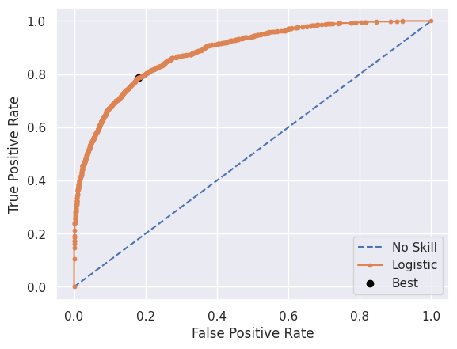

```python
threshold5 = best_threshold(model5)
```

### Loss and accuracy

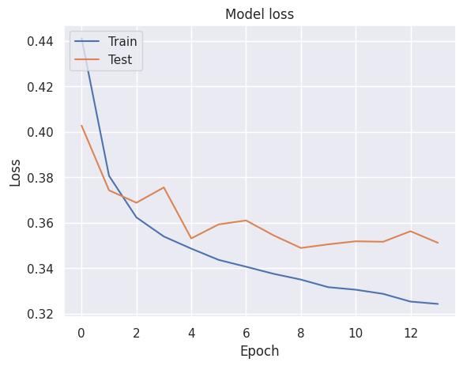

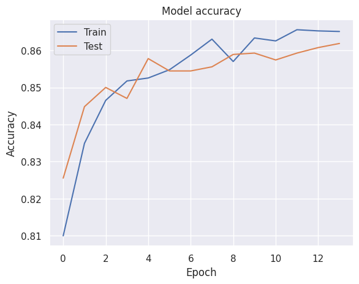

```python
# Predicting target values (y_pred5) using 'model5' on the validation data (X_val).
y_pred5 = model5.predict(X_val)

# Applying a threshold to the predictions.
y_pred5 = (y_pred5 > threshold5)
graphs_and_report(history5, y_pred5)
```

### Classification report

```python
cr5 = metrics.classification_report(y_val, y_pred5,digits=3)
print(cr5)
```

```
              precision    recall  f1-score   support

           0      0.922     0.816     0.866      2147
           1      0.506     0.732     0.598       553

    accuracy                          0.799      2700
   macro avg      0.714     0.774     0.732      2700
weighted avg      0.837     0.799     0.811      2700
```

### Confusion matrix

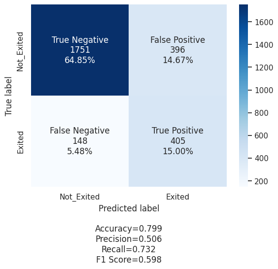

```python
cm5 = confusion_matrix(y_val, y_pred5)
labels = ['True Negative', 'False Positive', 'False Negative', 'True Positive']
categories = ['Not_Exited', 'Exited']
make_confusion_matrix(cm5,
                      group_names=labels,
                      categories=categories,
                      cmap='Blues')
```

### Observations

Precision (0): 0.922

- Precision measures the accuracy of positive predictions for class 0. A high value indicates that when the model predicts class 0, it's usually correct.

Recall (0): 0.816

- Recall (or Sensitivity) measures the ability of the model to correctly identify actual class 0 instances. It tells us what proportion of actual class 0 cases were correctly predicted.

F1-Score (0): 0.866

- The F1-Score is the harmonic mean of precision and recall for class 0. It provides a balance between precision and recall for this class.

Precision (1): 0.506

- Precision for class 1. Indicates how accurate the model's positive predictions are for class 1.

Recall (1): 0.732

- Recall for class 1. Measures the ability to correctly identify actual class 1 instances.

F1-Score (1): 0.598

- F1-Score for class 1. Similar to class 0, it balances precision and recall for class 1.

### Model Improvement: Neural Network model with balanced data

### Model 6

```python
# Applying SMOTE (Synthetic Minority Over-sampling Technique) to the training data
sm = SMOTE(random_state=42)
X_train, y_train = sm.fit_resample(X_train, y_train)

# Printing the shape of the training data after upsampling
print('After UpSampling, the shape of train_X: {}'.format(X_train.shape))
print('After UpSampling, the shape of train_y: {} \n'.format(y_train.shape))
```

```
After UpSampling, the shape of train_X: (10044, 11)
After UpSampling, the shape of train_y: (10044,)
```

```python
# Printing unique values and their counts in the 'y_train' array
print(np.unique(y_train, return_counts=True))
```

```
(array([0, 1]), array([5022, 5022]))
```

```python
import random
backend.clear_session()
# Fixing the seed for random number generators so that we can ensure we receive the same output everytime
np.random.seed(42)
random.seed(42)
tf.random.set_seed(42)
```

```python
# Initializing the neural network model 'model6'
model6 = Sequential()

# Adding the input layer with 32 neurons and ReLU activation, using He uniform initialization,
# and specifying the input shape.
model6.add(Dense(32, activation='relu', kernel_initializer='he_uniform', input_shape=(11,)))

# Adding a dropout layer with a dropout rate of 20% to prevent overfitting.
model6.add(Dropout(0.2))

# Adding the second hidden layer with 16 neurons, ReLU activation, and He uniform initialization.
model6.add(Dense(16, activation='relu', kernel_initializer='he_uniform'))

# Adding another dropout layer with a dropout rate of 20%.
model6.add(Dropout(0.2))

# Adding the third hidden layer with 8 neurons, ReLU activation, and He uniform initialization.
model6.add(Dense(8, activation='relu', kernel_initializer='he_uniform'))

# Adding the output layer with one neuron and sigmoid activation for binary classification.
model6.add(Dense(1, activation='sigmoid'))

# Initializing the stochastic gradient descent (SGD) optimizer with a learning rate of 1e-3.
sgd = optimizers.SGD(learning_rate=1e-3)

# Compiling the model using binary cross-entropy loss and accuracy as a metric.
model6.compile(optimizer=sgd, loss='binary_crossentropy', metrics=['accuracy'])

# Printing a summary of the model architecture.
model6.summary()
```

[output not shown]

```python
# Training 'model6' on the training data (X_train, y_train) with validation data (X_val, y_val)
# for a maximum of 100 epochs using a batch size of 64.
# Early stopping is applied based on validation loss, as defined by the 'early_stop' callback.
history6 = model6.fit(X_train, y_train, validation_data=(X_val, y_val),
                      epochs=100, batch_size=64, callbacks=[early_stop])
```

### Tune the threshold using ROC-AUC

```
Best Threshold=0.468450, G-Mean=0.765
```

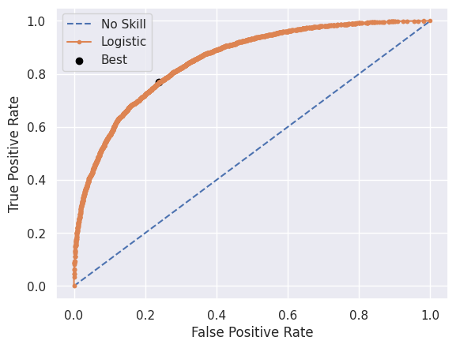

```python
threshold6 = best_threshold(model6)
```

### Loss and accuracy

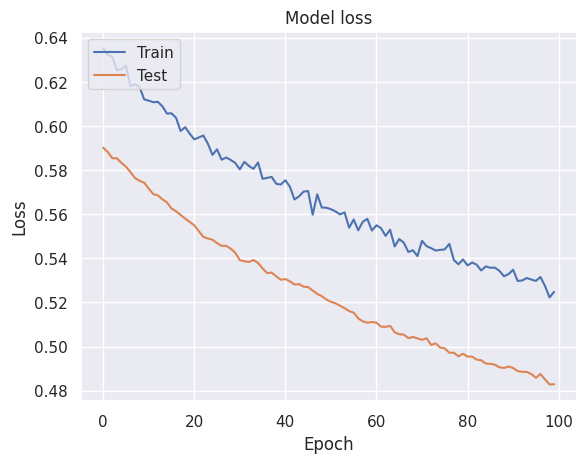

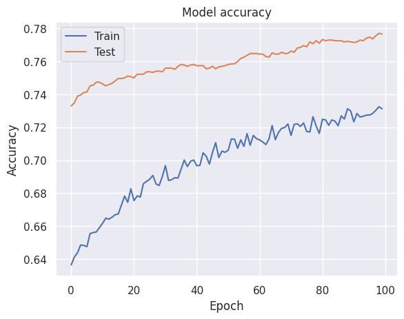

```python
# Predicting target values (y_pred6) using 'model6' on the validation data (X_val).
y_pred6 = model6.predict(X_val)

# Applying a threshold to the predictions.
y_pred6 = (y_pred6 > threshold6)

graphs_and_report(history6, y_pred6)
```

### Classification report

```python
cr6 = metrics.classification_report(y_val, y_pred6,digits=3)
print(cr6)
```

```
              precision    recall  f1-score   support

           0      0.915     0.768     0.835      2147
           1      0.445     0.722     0.550       553

    accuracy                          0.759      2700
   macro avg      0.680     0.745     0.693      2700
weighted avg      0.818     0.759     0.777      2700
```

### Confusion matrix

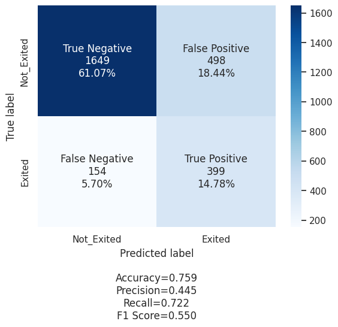

```python
cm6 = confusion_matrix(y_val, y_pred6)
labels = ['True Negative', 'False Positive', 'False Negative', 'True Positive']
categories = ['Not_Exited', 'Exited']
make_confusion_matrix(cm6,
                      group_names=labels,
                      categories=categories,
                      cmap='Blues')
```

### Observations

Precision (0): 0.915

- Precision measures the accuracy of positive predictions for class 0. In this case, it indicates that when the model predicts class 0, it's usually correct.

Recall (0): 0.768

- Recall (or Sensitivity) measures the ability of the model to correctly identify actual class 0 instances. It tells us what proportion of actual class 0 cases were correctly predicted.

F1-Score (0): 0.835

- The F1-Score is the harmonic mean of precision and recall for class 0. It provides a balance between precision and recall for this class.

Precision (1): 0.445

- Precision for class 1. Indicates how accurate the model's positive predictions are for class 1.

Recall (1): 0.722

- Recall for class 1. Measures the ability to correctly identify actual class 1 instances.

F1-Score (1): 0.550

- F1-Score for class 1. Similar to class 0, it balances precision and recall for class 1.

## Final Model

```python
for i in range(1,7):
  print(f'Model {i}'+'-'*20)
###  print(eval(f'cr{i}'))
```

[output not shown]

### Observations

Evaluating the models:

Model 1: It has a high precision for class 0 but a low recall for class 1, which suggests it may not be the best choice if you want to correctly identify class 1 instances.

Model 2: It has a higher recall for class 1 compared to Model 1, but its precision for class 1 is quite low. It also has a lower overall accuracy than Model 1.

Model 3: This model has a good balance between precision and recall for both classes, making it a reasonable choice. It also has a decent overall accuracy.

Model 4: While it has a high recall for class 1, its precision is low. The overall accuracy is also lower compared to other models.

Model 5: Model 5 shows a decent balance between precision and recall for both classes, along with a good overall accuracy.

### Conclusion

**Model 5 offers a good balance between recall and overall accuracy.**

## Actionable Insights and Recommendations

**What recommedations would you suggest to the bank?**

Customer Segmentation:

- Segment customers based on age groups, account balances, and credit scores. Tailor marketing and service strategies for each segment. For example, offer retirement planning services for older customers and financial education for those with lower balances or credit scores.

Retention Programs:

- Develop customer retention programs that incentivize and reward active members. These programs could include loyalty rewards, discounts, or special offers for long-standing customers who actively use the bank's services.

Cross-Selling:

- Implement targeted cross-selling strategies to increase the number of products per customer. Identify complementary financial products and services to offer based on individual customer profiles. Ensure that the cross-selling approach is customer-centric and adds value.

Customer Feedback:

- Collect regular feedback from customers to understand their needs, concerns, and reasons for potential churn. Use surveys, focus groups, and digital feedback channels to gather insights.

Enhanced Customer Experience:

- Continuously improve the overall customer experience. Ensure that online and mobile banking platforms are user-friendly and provide seamless services. Address any issues related to account management, transactions, or customer support promptly.